# Lab: Multigroup Models and Measurement Invariance

Today’s lab meeting consists of two exercises.

Practical information:

- All the data files for these exercises can be found at the course platform (i.e., UU learning platform). Make sure to download and unzip the .zip file. The folder containing the data files will probably be your working directory.

Short description of exercises:

- Exercise 1 addresses multigroup regression and
- Exercise 2 addresses measurement invariance.

# 1 Exercise 1: Multigroup Regression

In this exercise, we extend the regression analysis of Day 1 to a multi-group analysis, like also done in today’s lecture. Thus, use the data file **popular_regr.txt** again and remember that -99 and -999 denote missings.

In the multigroup analysis, you want to predict levels of socially desirable answering patterns of adolescents (sw) by overt (overt) and covert antisocial behaviour (covert), for males and females (gender).

## 1.1 Exercise 1a

Create lavaan code for a multigroup comparison between males and females to answer the question whether there are differences in the regression coefficients between sw and overt and between sw and covert. You will now obtain results for males and females separately.

*Are there differences between males and females?*

*What do the confidence intervals indicate?*

Bear in mind that

- Gender is a grouping variable consisting of two levels. By making it a factor, one can easily assign labels (e.g., ‘males’ and ‘females’) to it.
- To run a multigroup analysis (for gender), the lavaan function needs the argument: group = “gender”.
- To also obtain the confidence intervals use: ci = TRUE.
- We did not use FIML in the regression analysis of Day 1. Therefore, we will also not do that here.

## 1.2 Exercise 1b

Compute a significance test (Wald test) to test whether the regression coefficients for males and females are the same or not.

For a lavaan object (with label names!), one can do this with lavTestWald(fit, constraints = “<insert equality restriction>”).

Now, there is only one equation for both groups, so one needs to assign two labels (say, b1_m and b1_f) to the ‘single’ parameter, by using ’c(b1_m,b1_f)*’. This needs to be done for both regression parameters of interest.

*What do you conclude about the equality of regression parameters?*

## 1.3 Answers Exercise 1

**Click to show answers**

**Installing and loading Lavaan**

```r
if (!require("lavaan")) install.packages("lavaan", dependencies = TRUE)
```

```r
library(lavaan)
```

**Read in data**

```r
data_regr <- read.table("popular_regr.txt", header = T)

# If data without header, then:
colnames(data_regr) <- c("respnr", "Dutch", "gender", "sw", "covert", "overt")
```

**Denote missing values**

Missing values are labelled -99 and -999, so set this to NA:

```r
data_regr[sapply(data_regr, function(x) as.character(x) %in% c("-99", "-999"))] <- NA
```

If you forget to tell R that -99 and -999 are used to denote missing data, these values will be treated as being observed.

**Recoding variables**

Besides sw, overt, and covert, we now also use the variable gender. Since we read in a text file, there is no information about measurement level. Thus, we want to denote that the variable ‘gender’ is a factor, although it is not necessary in case of two levels. It is, however, helpful in assigning names to the levels.

```r
data_regr$gender <- factor(data_regr$gender, labels = c("male", "female"))

# summary(data_regr$gender)
```

**Specify the multigroup regression model**

Now, let us run a multigroup regression model predicting levels of socially desirable answering patterns of adolescents (sw) using the predictors overt (overt) and covert antisocial behaviour (covert), for both males and females.

To run a multigroup regression with lavaan, we need to add: group = “gender” to the lavaan function. It does not affect the model specification:

```r
model.regression <- "
  sw ~ overt + covert # regression
  sw ~~ sw            # residual variance
  sw ~ 1              # intercept
"
```

**Fit the multigroup regression model using the lavaan function**

To run a multigroup regression, we use the lavaan function and, as mentioned before, we need to add ‘group = “gender”’ to this function:

```r
fit_MGregr <- lavaan(model = model.regression, data = data_regr, group = "gender")  # multigroup specification
```

**Summary of the model**

```r
summary(fit_MGregr, standardized = TRUE, fit.measures = TRUE, rsquare = TRUE, ci = TRUE)
```

```
lavaan 0.6-21 ended normally after 1 iteration

  Estimator                                         ML
  Optimization method                           NLMINB
  Number of model parameters                         8

  Number of observations per group:               Used       Total
    male                                           756         824
    female                                         581         660

Model Test User Model:

  Test statistic                                 0.000
  Degrees of freedom                                 0
  Test statistic for each group:
    male                                         0.000
    female                                       0.000

Model Test Baseline Model:

  Test statistic                               443.954
  Degrees of freedom                                 4
  P-value                                        0.000

User Model versus Baseline Model:

  Comparative Fit Index (CFI)                    1.000
  Tucker-Lewis Index (TLI)                       1.000

Loglikelihood and Information Criteria:

  Loglikelihood user model (H0)              -1151.916
  Loglikelihood unrestricted model (H1)      -1151.916

  Akaike (AIC)                                2319.833
  Bayesian (BIC)                              2361.418
  Sample-size adjusted Bayesian (SABIC)       2336.006

Root Mean Square Error of Approximation:

```

[output cut: 42 more lines]

```
  sw ~
    overt            -0.232    0.081   -2.871    0.004   -0.390   -0.074   -0.232   -0.112
    covert           -0.558    0.045  -12.295    0.000   -0.647   -0.469   -0.558   -0.478

Intercepts:
                   Estimate  Std.Err  z-value  P(>|z|) ci.lower ci.upper   Std.lv  Std.all
   .sw                5.062    0.106   47.703    0.000    4.854    5.270    5.062    7.572

Variances:
                   Estimate  Std.Err  z-value  P(>|z|) ci.lower ci.upper   Std.lv  Std.all
   .sw                0.318    0.019   17.044    0.000    0.282    0.355    0.318    0.712

R-Square:
                   Estimate
    sw                0.288
```

**Parameter estimates**

You can ask for the parameter estimates in a few different ways, as outlined below.

```r
coef(fit_MGregr)  # unstandardized regression parameters
```

```
    sw~overt    sw~covert       sw~~sw         sw~1  sw~overt.g2 sw~covert.g2    sw~~sw.g2      sw~1.g2
      -0.278       -0.497        0.336        4.930       -0.232       -0.558        0.318        5.062
```

```r
parameterEstimates(fit_MGregr)  # all unstandardized parameters - with extra information
```

```
      lhs op    rhs block group    est    se       z pvalue ci.lower ci.upper
1      sw  ~  overt     1     1 -0.278 0.059  -4.719  0.000   -0.393   -0.163
2      sw  ~ covert     1     1 -0.497 0.039 -12.818  0.000   -0.573   -0.421
3      sw ~~     sw     1     1  0.336 0.017  19.442  0.000    0.302    0.369
4      sw ~1            1     1  4.930 0.085  57.938  0.000    4.763    5.097
5   overt ~~  overt     1     1  0.157 0.000      NA     NA    0.157    0.157
6   overt ~~ covert     1     1  0.102 0.000      NA     NA    0.102    0.102
7  covert ~~ covert     1     1  0.361 0.000      NA     NA    0.361    0.361
8   overt ~1            1     1  1.385 0.000      NA     NA    1.385    1.385
9  covert ~1            1     1  1.852 0.000      NA     NA    1.852    1.852
10     sw  ~  overt     2     2 -0.232 0.081  -2.871  0.004   -0.390   -0.074
11     sw  ~ covert     2     2 -0.558 0.045 -12.295  0.000   -0.647   -0.469
12     sw ~~     sw     2     2  0.318 0.019  17.044  0.000    0.282    0.355
13     sw ~1            2     2  5.062 0.106  47.703  0.000    4.854    5.270
14  overt ~~  overt     2     2  0.104 0.000      NA     NA    0.104    0.104
15  overt ~~ covert     2     2  0.080 0.000      NA     NA    0.080    0.080
16 covert ~~ covert     2     2  0.328 0.000      NA     NA    0.328    0.328
17  overt ~1            2     2  1.249 0.000      NA     NA    1.249    1.249
18 covert ~1            2     2  2.060 0.000      NA     NA    2.060    2.060
```

```r
standardizedSolution(fit_MGregr)  # all standardized parameters - with extra information
```

```
      lhs op    rhs group est.std    se       z pvalue ci.lower ci.upper
1      sw  ~  overt     1  -0.161 0.034  -4.789  0.000   -0.227   -0.095
2      sw  ~ covert     1  -0.438 0.030 -14.451  0.000   -0.498   -0.379
3      sw ~~     sw     1   0.721 0.026  28.073  0.000    0.671    0.772
4      sw ~1            1   7.228 0.145  49.849  0.000    6.944    7.512
5   overt ~~  overt     1   1.000 0.000      NA     NA    1.000    1.000
6   overt ~~ covert     1   0.428 0.000      NA     NA    0.428    0.428
7  covert ~~ covert     1   1.000 0.000      NA     NA    1.000    1.000
8   overt ~1            1   3.500 0.000      NA     NA    3.500    3.500
9  covert ~1            1   3.080 0.000      NA     NA    3.080    3.080
10     sw  ~  overt     2  -0.112 0.039  -2.891  0.004   -0.187   -0.036
11     sw  ~ covert     2  -0.478 0.034 -14.210  0.000   -0.544   -0.412
12     sw ~~     sw     2   0.712 0.029  24.287  0.000    0.655    0.770
13     sw ~1            2   7.572 0.175  43.369  0.000    7.230    7.914
14  overt ~~  overt     2   1.000 0.000      NA     NA    1.000    1.000
15  overt ~~ covert     2   0.435 0.000      NA     NA    0.435    0.435
16 covert ~~ covert     2   1.000 0.000      NA     NA    1.000    1.000
17  overt ~1            2   3.882 0.000      NA     NA    3.882    3.882
18 covert ~1            2   3.596 0.000      NA     NA    3.596    3.596
```

**Model fit measures**

You can ask for the model fit measures in a few different ways, as outlined below.

```r
fitMeasures(fit_MGregr)  # many model fit measures
```

```
                 npar                  fmin                 chisq                    df                pvalue        baseline.chisq           baseline.df       baseline.pvalue                   cfi                   tli                  nnfi                   rfi                   nfi               …
                8.000                 0.000                 0.000                 0.000                    NA               443.954                 4.000                 0.000                 1.000                 1.000                 1.000                 1.000                 1.000               …
```

```r
fitMeasures(fit_MGregr, c("cfi", "tli", "rmsea", "srmr"))  # ask for specific model fit measures
```

```
  cfi   tli rmsea  srmr
    1     1     0     0
```

```r
inspect(fit_MGregr, "r2")  # R-square (for sw)
```

```
$male
   sw
0.279

$female
   sw
0.288
```

```r
# Technical output
lavInspect(fit_MGregr)  # Comparable to TECH1 in Mplus
```

```
$male
$male$lambda
       sw overt covert
sw      0     0      0
overt   0     0      0
covert  0     0      0

$male$theta
       sw overt covert
sw      0
overt   0     0
covert  0     0      0

$male$psi
       sw overt covert
sw      3
overt   0     0
covert  0     0      0

$male$beta
       sw overt covert
sw      0     1      2
overt   0     0      0
covert  0     0      0

$male$nu
       intrcp
sw          0
overt       0
covert      0

$male$alpha
       intrcp
sw          4
overt       0
covert      0


$female
$female$lambda
```

[output cut: 19 more lines]

```
sw      0     5      6
overt   0     0      0
covert  0     0      0

$female$nu
       intrcp
sw          0
overt       0
covert      0

$female$alpha
       intrcp
sw          8
overt       0
covert      0
```

**Plot the results**

```r
if (!require("lavaanPlot")) install.packages("lavaanPlot")  # install this package first (once)
library(lavaanPlot)
lavaanPlot(model = fit_MGregr, node_options = list(shape = "box", fontname = "Helvetica"),
    edge_options = list(color = "grey"), coefs = T, stand = T, covs = T)  # plot
```

[interactive chart not shown]

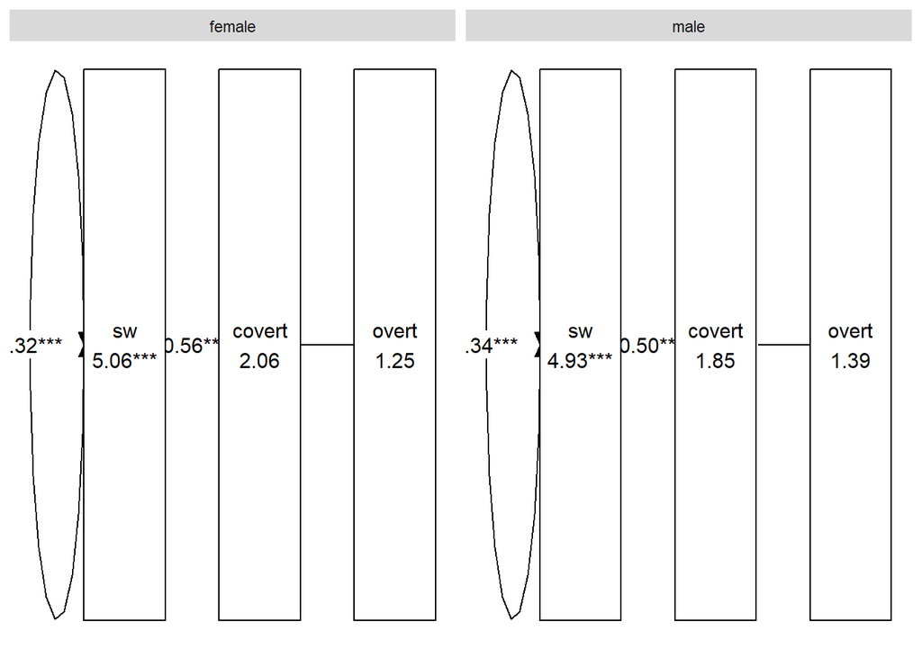

```r
# Note: I ask here for the standardized estimates

# Alternative
if (!require("tidySEM")) install.packages("tidySEM")  # install this package first (once)
library(tidySEM)
graph_sem(fit_MGregr)  # plot
```

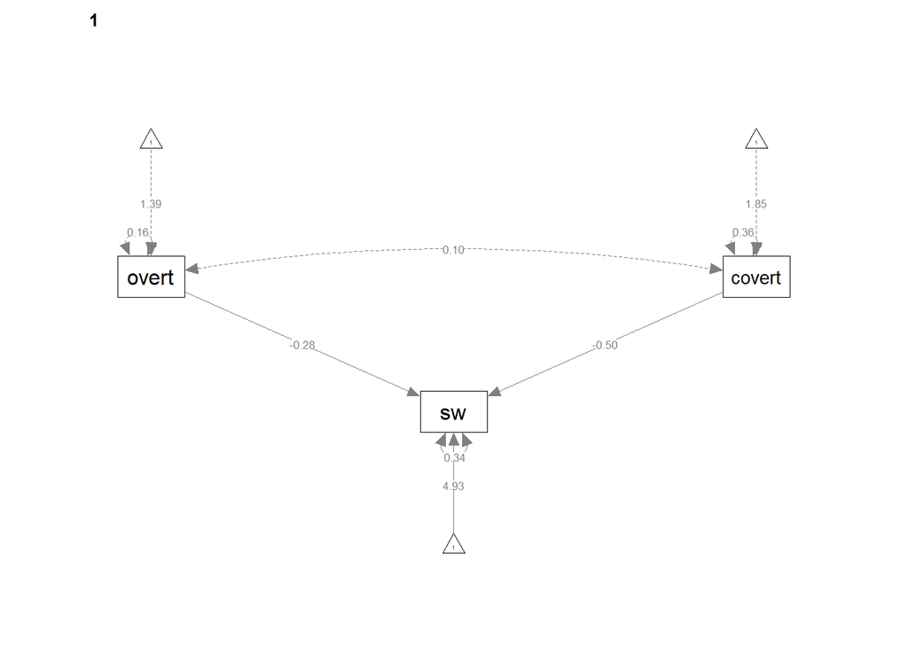

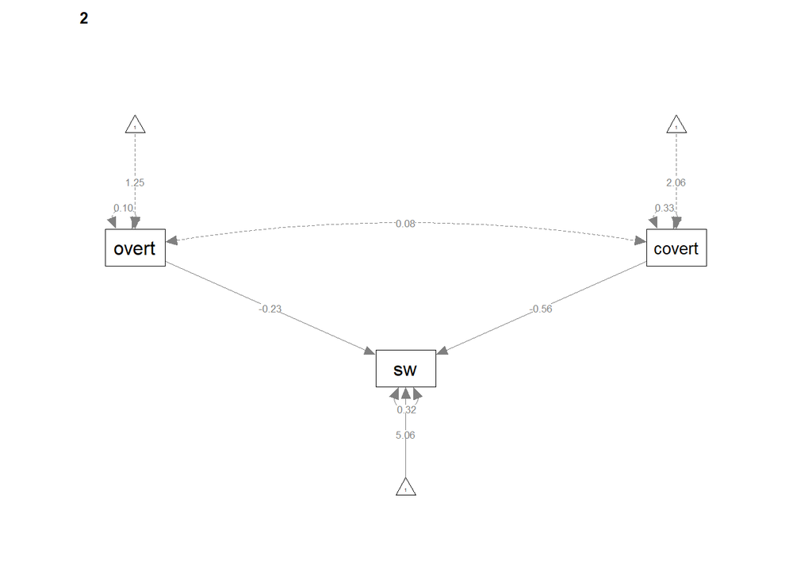

```r
# Another alternative
if (!require("semPlot")) install.packages("semPlot")  # install this package first (once)
library(semPlot)
semPaths(fit_MGregr, "par", weighted = FALSE, nCharNodes = 7, shapeMan = "rectangle",
    sizeMan = 8, sizeMan2 = 5)  # plot
```

[output not shown]

**Possible conclusions**

- The standardized effect of covert on sw appears to be stronger for females (-0.478) than males (-0.438) and reverse for the effect of overt (-0.161 for males compared to -0.112 for females).
- However, the confidence intervals for sw on covert and overt show a large overlap for males and females.

  The regression coefficients for the males are included in the confidence intervals for the females and vice versa.

Next, we are going to test whether the differences between the regression coefficients for males and females are statistically significant.

**Test equality of the regression coefficients**

Next, we want to test whether the regression coefficients for males and females are the same.

Note: One should actually do this for comparable parameters, which often comes down to inspecting standardized parameters. Unfortunately, this is difficult when using lavaan (or Mplus for that matter). However, since we look at the same relationship for two different groups, the comparability of the estimates may not be a problem. Moreover, the variances of the predictors and dependent variable are about the same for both groups, so we can probably compare the unstandardized parameters as well.

Now, we want to constrain ‘a single parameter’ to be equal across two groups. Therefore, we need to label this parameter for both groups, so using 2 labels. This we need to do for both regression coefficient parameters.

First, specify the model:

```r
model.regression_equal <- "
  # model with labeled parameters
  sw ~ c(b1_m,b1_f)*overt + c(b2_m,b2_f)*covert # regression
  sw ~~ sw                                      # residual variance
  sw ~ 1                                        # intercept
"
# or model.regression <- ' # regression model sw ~ c(b1_m,b1_f)*overt +
# c(b2_m,b2_f)*covert # add intercept sw ~ 1 # residual variance sw ~~ sw #
# means and (co)variances of the predictors overt ~ 1 covert ~ 1 overt ~~ overt
# covert ~~ covert covert ~~ overt '
```

Next, fit the model:

```r
# Fit model
fit_MGregr_equal <- lavaan(model = model.regression_equal, data = data_regr, group = "gender")  # multigroup specification
```

Last, conduct a Wald test:

```r
lavTestWald(fit_MGregr_equal, constraints = "b1_m == b1_f; b2_m == b2_f")
```

```
$stat
[1] 1.035523

$df
[1] 2

$p.value
[1] 0.5958527

$se
[1] "standard"
```

The Wald test with df=2 is 1.036, with $p$ = 0.596. Thus, we do not reject the null that the two regression coefficients for both groups are equal. Hence, we conclude that there is no evidence for a difference between b1_m and b1_f and between b2_m and b2_f. Stated otherwise, we conclude that the estimates are the same for both groups.

In case one wants the model results for which the regression coefficients are the same:

```r
# Model specification
model.regression_equal <- "
  # model with labeled parameters
  sw ~ c(b1_m,b1_f)*overt + c(b2_m,b2_f)*covert # regression
  sw ~~ sw                                      # residual variance
  sw ~ 1                                        # intercept
  #
  # constraints
  b1_m == b1_f; b2_m == b2_f
"

# Fit the model
fit_MGregr_equal <- lavaan(model = model.regression_equal, data = data_regr, group = "gender")  # multigroup specification

# Model summary
summary(fit_MGregr_equal, standardized = TRUE, fit.measures = TRUE)
```

```
lavaan 0.6-21 ended normally after 14 iterations

  Estimator                                         ML
  Optimization method                           NLMINB
  Number of model parameters                         8
  Number of equality constraints                     2

  Number of observations per group:               Used       Total
    male                                           756         824
    female                                         581         660

Model Test User Model:

  Test statistic                                 1.035
  Degrees of freedom                                 2
  P-value (Chi-square)                           0.596
  Test statistic for each group:
    male                                         0.436
    female                                       0.599

Model Test Baseline Model:

  Test statistic                               443.954
  Degrees of freedom                                 4
  P-value                                        0.000

User Model versus Baseline Model:

  Comparative Fit Index (CFI)                    1.000
  Tucker-Lewis Index (TLI)                       1.004

Loglikelihood and Information Criteria:

  Loglikelihood user model (H0)              -1152.434
  Loglikelihood unrestricted model (H1)      -1151.916

  Akaike (AIC)                                2316.868
  Bayesian (BIC)                              2348.057
  Sample-size adjusted Bayesian (SABIC)       2328.997

```

[output cut: 36 more lines]

```
Group 2 [female]:

Regressions:
                   Estimate  Std.Err  z-value  P(>|z|)   Std.lv  Std.all
  sw ~
    overt   (b1_f)   -0.261    0.048   -5.476    0.000   -0.261   -0.127
    covert  (b2_f)   -0.523    0.029  -17.738    0.000   -0.523   -0.453

Intercepts:
                   Estimate  Std.Err  z-value  P(>|z|)   Std.lv  Std.all
   .sw                5.026    0.068   73.571    0.000    5.026    7.599

Variances:
                   Estimate  Std.Err  z-value  P(>|z|)   Std.lv  Std.all
   .sw                0.319    0.019   17.044    0.000    0.319    0.729
```

```r
fitMeasures(fit_MGregr_equal, c("cfi", "tli", "rmsea", "srmr"))  # alternative for specific fit measures
```

```
  cfi   tli rmsea  srmr
1.000 1.004 0.000 0.009
```

# 2 Exercise 2: Measurement Invariance

In this exercise, you will do measurement invariance analyses. You will use data regarding Prolonged Grief Disorder, contained in **PGDdata2.txt**, where missing data is denoted by -999. The data set consists of the grouping variable Kin2 (with two levels: partner and else) and 5 items taken from the Inventory of Complicated Grief:

1. Yearning
2. Part of self died
3. Difficulty accepting the loss
4. Avoiding reminders of deceased
5. Bitterness about the loss

For more information, you are referred to the pdf of Boelen et al. (2010) in your (unzipped) Data files folder.

## 2.1 Exercise 2a

Run a 1-factor CFA on the data set ignoring the multigroup structure, using the default parameterization in the cfa() function.

*How many subjects are there?*

*How about the fit of the model?*

*Which item has the weakest contribution to the latent factor (in terms of standardized factor loading and explained variance)?*

## 2.2 Exercise 2b

Run a 1-factor multigroup CFA on the data, using: group = “Kin”.

*How many subjects are there per group?*

## 2.3 Exercise 2c

Test for configural, metric (weak), and scalar (strong) invariance:

- Configural: this is the model run in 2b.
- Weak: In the cfa function, one should add: group.equal = “loadings”
- Strong: In the cfa function, one should add: group.equal = c(“intercepts”, “loadings”)

One can compare these models with: *lavTestLRT()* or *anova()*, both give the same results.

*What is the model fit in the configural, metric (weak) and scalar (strong) invariant model?*

*Which model do you prefer?*

## 2.4 Exercise 2d

Add constraints such that also the residual variances are constrained to be the same for both groups.

**Click to show a hint**

In the cfa function, in the group.equal argument, one should add “residuals”.

Check for AIC and BIC differences and use the Chi-square difference test, by using the lavTestLRT() or anova() function.

*Did the model get significantly worse?*

## 2.5 Answers Exercise 2

**Click to show answers**

**Read in data**

```r
data_PGD <- read.table("PGDdata2.txt", header = T)
```

**Denote missing values and categorical variables**

```r
data_PGD[sapply(data_PGD, function(x) as.character(x) %in% c("-999"))] <- NA

data_PGD$Kin2 <- factor(data_PGD$Kin2, labels = c("partner", "else"))

# summary(data_PGD$Kin2)
```

**Data screening: Item correlations**

The correlations for the items of interest (i.e., b1pss1, b2pss2, b3pss3, b4pss4, and b5pss5) are:

```r
if (!require("Hmisc")) install.packages("Hmisc", dependencies = TRUE)
library(Hmisc)

res <- rcorr(as.matrix(data_PGD[, 2:6]))  # rcorr() accepts matrices only
round(res$r, 3)  # Correlation matrix (rounded to 3 decimals)
```

```
       b1pss1 b2pss2 b3pss3 b4pss4 b5pss5
b1pss1  1.000  0.418  0.523  0.495  0.515
b2pss2  0.418  1.000  0.319  0.285  0.345
b3pss3  0.523  0.319  1.000  0.481  0.473
b4pss4  0.495  0.285  0.481  1.000  0.477
b5pss5  0.515  0.345  0.473  0.477  1.000
```

**One-Factor CFA**

Specify and fit the model, then obtain the summary and fit measures:

```r
# Specify:
model.1CFA <- "
 F  =~ b1pss1 + b2pss2 + b3pss3 + b4pss4 + b5pss5
"

# Fit:
fit_1CFA <- cfa(model.1CFA, data = data_PGD, missing = "fiml", fixed.x = F)  # Specify FIML

# Summary:
summary(fit_1CFA, standardized = T)
```

```
lavaan 0.6-21 ended normally after 22 iterations

  Estimator                                         ML
  Optimization method                           NLMINB
  Number of model parameters                        15

  Number of observations                           571
  Number of missing patterns                         3

Model Test User Model:

  Test statistic                                 8.401
  Degrees of freedom                                 5
  P-value (Chi-square)                           0.135

Parameter Estimates:

  Standard errors                             Standard
  Information                                 Observed
  Observed information based on                Hessian

Latent Variables:
                   Estimate  Std.Err  z-value  P(>|z|)   Std.lv  Std.all
  F =~
    b1pss1            1.000                               0.751    0.759
    b2pss2            0.452    0.042   10.762    0.000    0.340    0.494
    b3pss3            0.833    0.058   14.420    0.000    0.625    0.691
    b4pss4            0.770    0.055   13.880    0.000    0.578    0.667
    b5pss5            0.817    0.057   14.331    0.000    0.613    0.690

Intercepts:
                   Estimate  Std.Err  z-value  P(>|z|)   Std.lv  Std.all
   .b1pss1            1.235    0.041   29.830    0.000    1.235    1.248
   .b2pss2            0.461    0.029   16.010    0.000    0.461    0.670
   .b3pss3            0.976    0.038   25.772    0.000    0.976    1.079
   .b4pss4            1.011    0.036   27.827    0.000    1.011    1.165
   .b5pss5            0.676    0.037   18.145    0.000    0.676    0.760

Variances:
                   Estimate  Std.Err  z-value  P(>|z|)   Std.lv  Std.all
   .b1pss1            0.414    0.037   11.233    0.000    0.414    0.423
   .b2pss2            0.357    0.023   15.595    0.000    0.357    0.756
   .b3pss3            0.428    0.033   13.141    0.000    0.428    0.522
   .b4pss4            0.418    0.031   13.610    0.000    0.418    0.556
   .b5pss5            0.414    0.032   13.149    0.000    0.414    0.524
    F                 0.564    0.059    9.522    0.000    1.000    1.000
```

```r
# Fit statistics:
fitMeasures(fit_1CFA, c("chisq", "df", "pvalue", "cfi", "tli", "rmsea", "srmr"))
```

```
 chisq     df pvalue    cfi    tli  rmsea   srmr
 8.401  5.000  0.135  0.996  0.991  0.035  0.016
```

```r
# Technical output
lavInspect(fit_1CFA)
```

```
$lambda
       F
b1pss1 0
b2pss2 1
b3pss3 2
b4pss4 3
b5pss5 4

$theta
       b1pss1 b2pss2 b3pss3 b4pss4 b5pss5
b1pss1      5
b2pss2      0      6
b3pss3      0      0      7
b4pss4      0      0      0      8
b5pss5      0      0      0      0      9

$psi
   F
F 10

$nu
       intrcp
b1pss1     11
b2pss2     12
b3pss3     13
b4pss4     14
b5pss5     15

$alpha
  intrcp
F      0
```

The number of observations is 571. Thus, there are 571 subjects/persons.

Using the rules of thumb, we can conclude that the fit of the model is acceptable. Namely, CFI/TLI > .95, RMSEA < .06, and SRMR < .08.

**One-factor Multigroup CFA**

Specify and fit the model, then obtain the summary and fit measures:

```r
# Specify:
model.1CFA <- "
 F  =~ b1pss1 + b2pss2 + b3pss3 + b4pss4 + b5pss5
"

# Fit:
fit_MG1CFA <- cfa(model.1CFA, data = data_PGD, group = "Kin2", missing = "fiml",
    fixed.x = F)  # Specify FIML

# Summary:
summary(fit_MG1CFA, standardized = T)
```

```
lavaan 0.6-21 ended normally after 27 iterations

  Estimator                                         ML
  Optimization method                           NLMINB
  Number of model parameters                        30

  Number of observations per group:
    partner                                        190
    else                                           379
  Number of missing patterns per group:
    partner                                          3
    else                                             1

Model Test User Model:

  Test statistic                                11.329
  Degrees of freedom                                10
  P-value (Chi-square)                           0.332
  Test statistic for each group:
    partner                                      8.989
    else                                         2.340

Parameter Estimates:

  Standard errors                             Standard
  Information                                 Observed
  Observed information based on                Hessian


Group 1 [partner]:

Latent Variables:
                   Estimate  Std.Err  z-value  P(>|z|)   Std.lv  Std.all
  F =~
    b1pss1            1.000                               0.698    0.711
    b2pss2            0.374    0.074    5.075    0.000    0.261    0.411
    b3pss3            0.939    0.120    7.810    0.000    0.655    0.705
    b4pss4            0.916    0.119    7.726    0.000    0.639    0.693
    b5pss5            0.956    0.124    7.715    0.000    0.667    0.684

```

[output cut: 30 more lines]

```
                   Estimate  Std.Err  z-value  P(>|z|)   Std.lv  Std.all
   .b1pss1            1.182    0.051   23.277    0.000    1.182    1.196
   .b2pss2            0.475    0.037   12.973    0.000    0.475    0.666
   .b3pss3            0.934    0.046   20.460    0.000    0.934    1.051
   .b4pss4            0.955    0.043   22.270    0.000    0.955    1.144
   .b5pss5            0.644    0.043   14.879    0.000    0.644    0.764

Variances:
                   Estimate  Std.Err  z-value  P(>|z|)   Std.lv  Std.all
   .b1pss1            0.385    0.044    8.837    0.000    0.385    0.394
   .b2pss2            0.359    0.029   12.468    0.000    0.359    0.706
   .b3pss3            0.425    0.038   11.035    0.000    0.425    0.538
   .b4pss4            0.401    0.035   11.401    0.000    0.401    0.575
   .b5pss5            0.366    0.034   10.733    0.000    0.366    0.516
    F                 0.592    0.073    8.074    0.000    1.000    1.000
```

```r
# Fit statistics:
fitMeasures(fit_MG1CFA, c("chisq", "df", "pvalue", "cfi", "tli", "rmsea", "srmr"))
```

```
 chisq     df pvalue    cfi    tli  rmsea   srmr
11.329 10.000  0.332  0.998  0.997  0.022  0.017
```

```r
# Technical output
lavInspect(fit_MG1CFA)
```

```
$partner
$partner$lambda
       F
b1pss1 0
b2pss2 1
b3pss3 2
b4pss4 3
b5pss5 4

$partner$theta
       b1pss1 b2pss2 b3pss3 b4pss4 b5pss5
b1pss1      5
b2pss2      0      6
b3pss3      0      0      7
b4pss4      0      0      0      8
b5pss5      0      0      0      0      9

$partner$psi
   F
F 10

$partner$nu
       intrcp
b1pss1     11
b2pss2     12
b3pss3     13
b4pss4     14
b5pss5     15

$partner$alpha
  intrcp
F      0


$`else`
$`else`$lambda
        F
b1pss1  0
b2pss2 16
b3pss3 17
```

[output cut: 11 more lines]

```
$`else`$psi
   F
F 25

$`else`$nu
       intrcp
b1pss1     26
b2pss2     27
b3pss3     28
b4pss4     29
b5pss5     30

$`else`$alpha
  intrcp
F      0
```

The number of observations per group are:

- 190 in the ‘partner’ group
- 379 in the ‘else’ group

**Measurement invariance testing**

Before one compares parameters across multiple groups in CFA, one first needs to establish measurement invariance. When data is continuous, testing for measurement invariance involves a fixed sequence of model comparison tests. A typical sequence involves three models:

Model 1: configural invariance.

- The same factor structure is imposed on all groups:

```r
# configural invariance - the same as fit_MG1CFA
fit_MG1CFA_ci <- cfa(model.1CFA, data = data_PGD, group = "Kin2", missing = "fiml",
    fixed.x = F)
# lavInspect(fit_MG1CFA_ci) npar = number of free parameters = 30 - 0 = 30,
# namely 30 parameters & 0 equality restrictions
```

Model 2: metric/weak invariance.

- The factor loadings are constrained to be equal across groups:

```r
# metric/weak invariance
fit_MG1CFA_wi <- cfa(model.1CFA, data = data_PGD, group = "Kin2", missing = "fiml",
    fixed.x = F, group.equal = "loadings")
# lavInspect(fit_MG1CFA_wi) npar = number of free parameters = 30-4 = 26,
# namely 30 parameters & 4 equality restrictions: on the 4 free factor loadings
# ('lambda')
```

*Note on constraints in output:*  
At the top of of the output, lavaan tells you with “1 == 16” that it restricts the 1st and 16th to-be-estimated parameters to be the same; and likewise for the other parameters.  
If you look at the output, you see that 1 (so, the 1st parameter of the to-be-estimated parameters) is the factor loading (lambda) of item b2pss2 of the group ‘partners’:

```
$partner
$partner$lambda
       F
b2pss2 1
```

Likewise, you find that 16 (so, the 16th parameter of the to-be-estimated parameters) is the factor loading (lambda) of item b2pss2 of the group ‘else’:

```
$`else`
$`else`$lambda
        F
b2pss2 16
```

So, lavaan restricts the factor loading (lambda) of item b2pss2 of the group ‘partners’ to be equal to the factor loading (lambda) of b2pss2 of the ‘else’ group.

*Continue with the analysis:*  
Model 3: scalar/strong invariance.

- The factor loadings and intercepts are constrained to be equal across groups:

```r
# scalar/strong invariance
fit_MG1CFA_si <- cfa(model.1CFA, data = data_PGD, group = "Kin2", missing = "fiml",
    fixed.x = F, group.equal = c("intercepts", "loadings"))
# lavInspect(fit_MG1CFA_si) npar = number of free parameters = 31-9 = 22,
# namely 31 parameters (now, also estimating alpha of the second group) & 9
# equality restrictions: on the 4 free factor loadings ('lambda') and on the 5
# intercepts ('nu')
```

*Note on number of parameters:*  
In each group, 5 intercepts (‘nu’) are estimated: if we would constrain these, we would be saying that the means across the two groups are equal. However, what we want to say is that the differences in observed means are completely explained by mean differences on the latent variables. Therefore, we constrain the intercepts across the groups (‘nu’), and free the latent mean(s) in one of the groups (‘alpha’): these represent the latent mean differences. Notably, when you have multiple groups, the latent mean(s) are freed (or you should free them) for all-but-one groups.  
Hence, the total number of parameters to be estimated here is 31.

*Continue with the analysis:*  
To compare the models the following code can be run:

```r
lavTestLRT(fit_MG1CFA_ci, fit_MG1CFA_wi, fit_MG1CFA_si)
```

```
Chi-Squared Difference Test

              Df    AIC    BIC  Chisq Chisq diff Df diff Pr(>Chisq)
fit_MG1CFA_ci 10 6488.1 6618.4 11.329
fit_MG1CFA_wi 14 6488.2 6601.1 19.417     8.0876       4    0.08842 .
fit_MG1CFA_si 18 6485.1 6580.6 24.297     4.8802       4    0.29982
---
Signif. codes:  0 '***' 0.001 '**' 0.01 '*' 0.05 '.' 0.1 ' ' 1
```

```r
# or: anova(fit_MG1CFA_ci, fit_MG1CFA_wi, fit_MG1CFA_si)
```

Because we provided three model fits, it produces two tests:

1. the first model versus the second model.
2. the second model versus the third model.

**Possible conclusions**

0. The configural model fits the data ($\chi^2(10) = 11.329, \ p = .33$):

```r
fitMeasures(fit_MG1CFA_ci, c("chisq", "df", "pvalue"))
```

```
 chisq     df pvalue
11.329 10.000  0.332
```

From there on, we evaluate whether the more constrained model does not fit the data worse than the less constrained model.

1. Because the first p-value is non-significant ($p = 0.088 > .05$), we conclude that:
- Weak invariance (equal factor loadings) is supported in this dataset.
- Stated otherwise: The metric invariance model does not fit worse than the configural model.
2. Because the second p-value is also non-significant ($p = 0.300 > .05$), we conclude that strong invariance (equal intercepts and factor loadings) is also supported:
- In SEM, one always prefer parsimony: the model with the most df. Thus, we prefer the scalar invariance model, where both factor loadings and intercepts are constrained (to be equal).
- Since the latent variable in the scalar model means the same thing across the two groups, we can compare values on the latent variable.

*Remark:* Let us say that the second p-value is significant:

- Then, strong invariance is not supported.
- Then, it is unwise to directly compare parameters across the two groups.

Alternatively or additionally, one could look at the AIC and/or BIC values. Since the AIC and BIC are the lowest for ‘MG1CFA_si’, we also conclude from this that there is strong invariance. We could even quantify the relative support:

```r
# In case you want to quantify the relative support (so, how much better).
# Based on the AIC:
fit_AIC <- lavTestLRT(fit_MG1CFA_ci, fit_MG1CFA_wi, fit_MG1CFA_si)$AIC
# or: fit_AIC <- anova(fit_MG1CFA_ci, fit_MG1CFA_wi, fit_MG1CFA_si)$AIC
# names(fit_AIC) <- c('ci', 'wi', 'si') # not needed fit_AIC if
# (!require('restriktor')) install.packages('restriktor', dependencies = TRUE)
library(restriktor)  # ?calc_ICweights
AIC_weights <- calc_ICweights(fit_AIC, hypo_names = c("ci", "wi", "si"))
# AIC_weights
AIC_weights$IC_weights  # 'si' (3rd model) is best
```

```
       ci        wi        si
0.1535707 0.1469894 0.6994399
```

```r
AIC_weights$ratio_IC_weights[3, 1:2]
```

```
   vs_ci    vs_wi
4.554515 4.758438
```

```r
# Note: More information in IC weights can be found in the Model Selection
# lecture.
```

The strong invariance model is about 4.55 times more supported than the configural model, and about 4.76 times more than the weak invariance (equal factor loadings) model.

**Plot**

A path diagram of the strong invariance model can be obtained via:

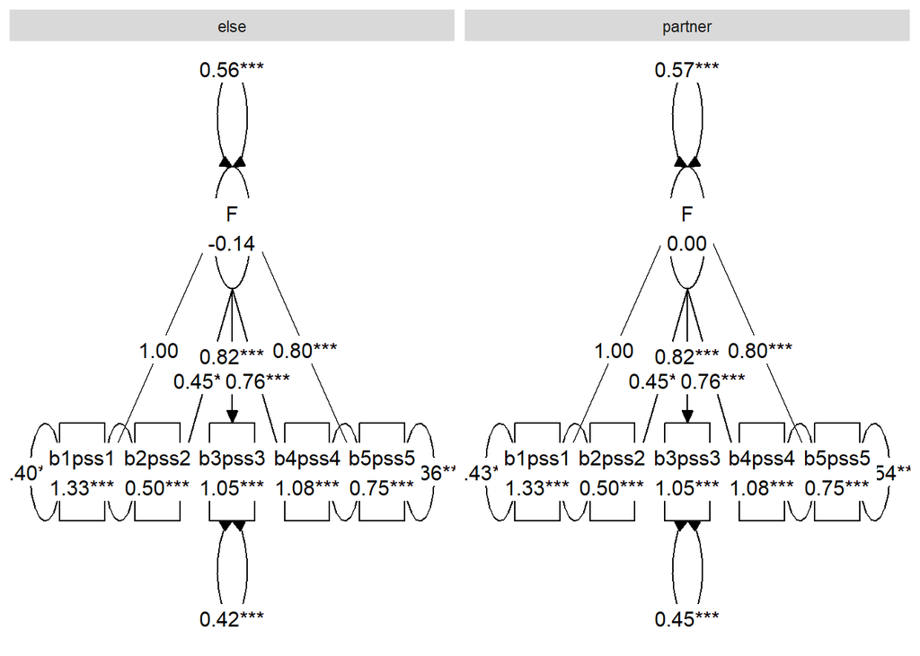

```r
if (!require("tidySEM")) install.packages("tidySEM")  # install this package first (once)
library(tidySEM)

graph_sem(fit_MG1CFA_si)  # plot
```

**Adding constraints**

Add constraints such that also the residual variances are constrained to be the same for both groups:

```r
# Fit model:
fit_MG1CFA_si_res <- cfa(model.1CFA, data = data_PGD, group = "Kin2", missing = "fiml",
    fixed.x = F, group.equal = c("intercepts", "loadings", "residuals"))  # constraints

# Fit measures
fitMeasures(fit_MG1CFA_si_res, c("chisq", "df", "pvalue", "cfi", "tli", "rmsea",
    "srmr"))
```

```
 chisq     df pvalue    cfi    tli  rmsea   srmr
34.565 23.000  0.057  0.985  0.987  0.042  0.057
```

```r
# Technical output
lavInspect(fit_MG1CFA_si_res)
```

```
Note: model contains equality constraints:

   lhs op rhs
1    1 ==  16
2    2 ==  17
3    3 ==  18
4    4 ==  19
5    5 ==  20
6    6 ==  21
7    7 ==  22
8    8 ==  23
9    9 ==  24
10  11 ==  26
11  12 ==  27
12  13 ==  28
13  14 ==  29
14  15 ==  30

$partner
$partner$lambda
       F
b1pss1 0
b2pss2 1
b3pss3 2
b4pss4 3
b5pss5 4

$partner$theta
       b1pss1 b2pss2 b3pss3 b4pss4 b5pss5
b1pss1      5
b2pss2      0      6
b3pss3      0      0      7
b4pss4      0      0      0      8
b5pss5      0      0      0      0      9

$partner$psi
   F
F 10

$partner$nu
```

[output cut: 29 more lines]

```
$`else`$psi
   F
F 25

$`else`$nu
       intrcp
b1pss1     26
b2pss2     27
b3pss3     28
b4pss4     29
b5pss5     30

$`else`$alpha
  intrcp
F     31
```

```r
# npar = number of free parameters = 31-14 = 17, namely 31 parameters (now,
# also estimating alpha of the second group) & 14 equality restrictions: on the
# 4 free factor loadings ('lambda'), on the 5 intercepts ('nu'), and on the 5
# residual variances ('theta')
```

Compare this model (fit_MG1CFA_si_res) to one without (fit_MG1CFA_si):

```r
lavTestLRT(fit_MG1CFA_si_res, fit_MG1CFA_si)  # or:
```

```
Chi-Squared Difference Test

                  Df    AIC    BIC  Chisq Chisq diff Df diff Pr(>Chisq)
fit_MG1CFA_si     18 6485.1 6580.6 24.297
fit_MG1CFA_si_res 23 6485.3 6559.2 34.565     10.268       5    0.06799 .
---
Signif. codes:  0 '***' 0.001 '**' 0.01 '*' 0.05 '.' 0.1 ' ' 1
```

```r
# anova(fit_MG1CFA_si_res, fit_MG1CFA_si)
```

**Possible conclusion**

Since $\Delta \chi^2(5) = 10.268, \ p= 0.068$, the equal-residual-variances model is not significantly worse. That is, the residual variances are also equal.

Bear in mind that, when we compare two models, we always prefer a more parsimonious model (= more df, that is, less parameters to be estimated).

*Remark:*  
Strict invariance is often very difficult to establish in practice. Van de Schoot et al. (2012) note that with the lack of strict invariance, groups can still be compared on the latent construct(s).  
Reference: Van de Schoot, R., Lugtig, P., & Hox, J. (2012). A checklist for testing measurement invariance. European Journal of Developmental Psychology, 9(4), 486–492.